# Mysterious Stones Results Discussion

Bonan Zhao

Nov 2, 2020

# Free responses analysis

Coding includes three aspects:

- **Rule type**: what type of causal rule does a free response belong to?
- **Categorization**: does the free response categorizes learning observations? If so, is the categorization on Active stone, Inactive stone, or both?
- **Feature sources**: when describing the feature changes of the result stone M, does the rule reference it to a constant change or a particular source?

## Rule Types

### Definition

- **Incompatible**: conflict with learning data
- **Partial**: explicitly describe part of the learning data (usually just one data point), leave the rest unmentioned
- **True_constant**: get the true rule with setting one M feature to a constant value
- **True_relative**: get the true rule where both M features are relative to the Active (A) or Inactive (R) stone
- **Vague**: get part of the true rules, leave the rest unmentioned; is broad about feature changes: darkens, changes, become a new shape etc (get finer analysis on these rules later)
- **Sophisticated**: over sophisticated than the true rules while also being true

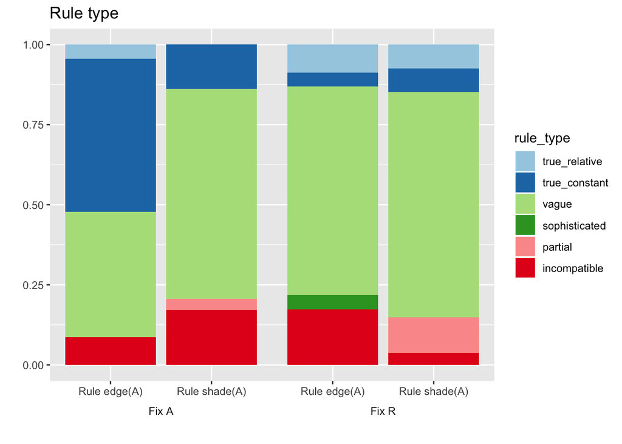

```r
glm(rule_type=='true_constant' ~ fix + rule_change,
    data=labels, family='binomial') %>% summary()
```

```
##
## Call:
## glm(formula = rule_type == "true_constant" ~ fix + rule_change,
##     family = "binomial", data = labels)
##
## Deviance Residuals:
##     Min       1Q   Median       3Q      Max
## -1.0545  -0.6281  -0.4475  -0.2466   2.6488
##
## Coefficients:
##                  Estimate Std. Error z value Pr(>|z|)
## (Intercept)       -0.2963     0.4042  -0.733  0.46350
## fixR              -1.9546     0.6854  -2.852  0.00435 **
## rule_changeshade  -1.2268     0.5786  -2.120  0.03398 *
## ---
## Signif. codes:  0 '***' 0.001 '**' 0.01 '*' 0.05 '.' 0.1 ' ' 1
##
## (Dispersion parameter for binomial family taken to be 1)
##
##     Null deviance: 95.064  on 101  degrees of freedom
## Residual deviance: 80.376  on  99  degrees of freedom
## AIC: 86.376
##
## Number of Fisher Scoring iterations: 5
```

```r
glm(rule_type=='true_constant'~ fix + rule_change + fix * rule_change,
    data=labels, family='binomial') %>% summary()
```

```
##
## Call:
## glm(formula = rule_type == "true_constant" ~ fix + rule_change +
##     fix * rule_change, family = "binomial", data = labels)
##
## Deviance Residuals:
##     Min       1Q   Median       3Q      Max
## -1.1407  -0.5448  -0.3923  -0.2982   2.5042
##
## Coefficients:
##                       Estimate Std. Error z value Pr(>|z|)
## (Intercept)           -0.08701    0.41742  -0.208  0.83488
## fixR                  -3.00403    1.10426  -2.720  0.00652 **
## rule_changeshade      -1.74557    0.68135  -2.562  0.01041 *
## fixR:rule_changeshade  2.31088    1.43157   1.614  0.10648
## ---
## Signif. codes:  0 '***' 0.001 '**' 0.01 '*' 0.05 '.' 0.1 ' ' 1
##
## (Dispersion parameter for binomial family taken to be 1)
##
##     Null deviance: 95.064  on 101  degrees of freedom
## Residual deviance: 77.596  on  98  degrees of freedom
## AIC: 85.596
##
## Number of Fisher Scoring iterations: 5
```

**No effects for other rule types.**

### Classify rule types

- **True_rules**: true_relative, true_constant
- **Other_compatible**: vague, partial,sophisticated
- **Incompatible**

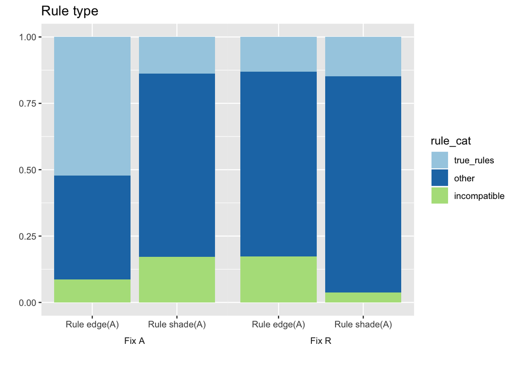

#### GLMs

```r
glm(rule_cat=='true_rules' ~ fix + rule_change,
    data=labels, family='binomial') %>% summary()
```

```
##
## Call:
## glm(formula = rule_cat == "true_rules" ~ fix + rule_change, family = "binomial",
##     data = labels)
##
## Deviance Residuals:
##     Min       1Q   Median       3Q      Max
## -1.0783  -0.6891  -0.6719  -0.4064   2.2517
##
## Coefficients:
##                  Estimate Std. Error z value Pr(>|z|)
## (Intercept)       -0.2377     0.3867  -0.615   0.5388
## fixR              -1.0793     0.5218  -2.069   0.0386 *
## rule_changeshade  -1.1356     0.5087  -2.232   0.0256 *
## ---
## Signif. codes:  0 '***' 0.001 '**' 0.01 '*' 0.05 '.' 0.1 ' ' 1
##
## (Dispersion parameter for binomial family taken to be 1)
##
##     Null deviance: 108.889  on 101  degrees of freedom
## Residual deviance:  99.428  on  99  degrees of freedom
## AIC: 105.43
##
## Number of Fisher Scoring iterations: 4
```

```r
glm(rule_cat=='true_rules' ~ fix + rule_change + fix * rule_change,
    data=labels, family='binomial') %>% summary()
```

```
##
## Call:
## glm(formula = rule_cat == "true_rules" ~ fix + rule_change +
##     fix * rule_change, family = "binomial", data = labels)
##
## Deviance Residuals:
##     Min       1Q   Median       3Q      Max
## -1.2146  -0.5663  -0.5448  -0.5287   2.0184
##
## Coefficients:
##                       Estimate Std. Error z value Pr(>|z|)
## (Intercept)            0.08701    0.41742   0.208  0.83488
## fixR                  -1.98413    0.74671  -2.657  0.00788 **
## rule_changeshade      -1.91959    0.68135  -2.817  0.00484 **
## fixR:rule_changeshade  2.06751    1.06820   1.936  0.05293 .
## ---
## Signif. codes:  0 '***' 0.001 '**' 0.01 '*' 0.05 '.' 0.1 ' ' 1
##
## (Dispersion parameter for binomial family taken to be 1)
##
##     Null deviance: 108.889  on 101  degrees of freedom
## Residual deviance:  95.574  on  98  degrees of freedom
## AIC: 103.57
##
## Number of Fisher Scoring iterations: 4
```

```r
glm(rule_cat=='other' ~ fix + rule_change,
    data=labels, family='binomial') %>% summary()
```

```
##
## Call:
## glm(formula = rule_cat == "other" ~ fix + rule_change, family = "binomial",
##     data = labels)
##
## Deviance Residuals:
##     Min       1Q   Median       3Q      Max
## -1.9209  -1.0490   0.5866   0.9043   1.3115
##
## Coefficients:
##                  Estimate Std. Error z value Pr(>|z|)
## (Intercept)       -0.3098     0.3725  -0.832   0.4056
## fixR               0.9900     0.4476   2.212   0.0270 *
## rule_changeshade   0.9927     0.4420   2.246   0.0247 *
## ---
## Signif. codes:  0 '***' 0.001 '**' 0.01 '*' 0.05 '.' 0.1 ' ' 1
##
## (Dispersion parameter for binomial family taken to be 1)
##
##     Null deviance: 131.19  on 101  degrees of freedom
## Residual deviance: 121.29  on  99  degrees of freedom
## AIC: 127.29
##
## Number of Fisher Scoring iterations: 4
```

```r
glm(rule_cat=='other' ~ fix + rule_change + fix * rule_change,
    data=labels, family='binomial') %>% summary()
```

```
##
## Call:
## glm(formula = rule_cat == "other" ~ fix + rule_change + fix *
##     rule_change, family = "binomial", data = labels)
##
## Deviance Residuals:
##     Min       1Q   Median       3Q      Max
## -1.8365  -0.9964   0.6400   0.8620   1.3699
##
## Coefficients:
##                       Estimate Std. Error z value Pr(>|z|)
## (Intercept)            -0.4418     0.4272  -1.034   0.3011
## fixR                    1.2685     0.6228   2.037   0.0417 *
## rule_changeshade        1.2403     0.5862   2.116   0.0344 *
## fixR:rule_changeshade  -0.5854     0.8913  -0.657   0.5113
## ---
## Signif. codes:  0 '***' 0.001 '**' 0.01 '*' 0.05 '.' 0.1 ' ' 1
##
## (Dispersion parameter for binomial family taken to be 1)
##
##     Null deviance: 131.19  on 101  degrees of freedom
## Residual deviance: 120.86  on  98  degrees of freedom
## AIC: 128.86
##
## Number of Fisher Scoring iterations: 4
```

**No effects for “incompatible”.**

## Categorization

Whether participants use “if”, “when”, “in case”, “unless” to separate types of stones, and if so, whether such categorization is applied on the Active stone (A), Inactive stone (R), or both.

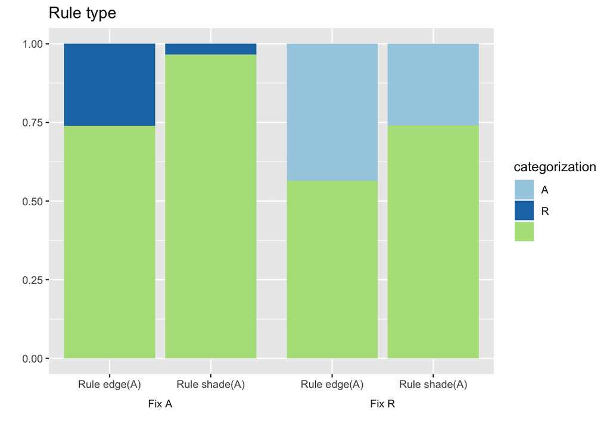

```r
glm(categorization!='' ~ fix + rule_change,
    data=labels, family='binomial') %>% summary()
```

```
##
## Call:
## glm(formula = categorization != "" ~ fix + rule_change, family = "binomial",
##     data = labels)
##
## Deviance Residuals:
##     Min       1Q   Median       3Q      Max
## -1.1504  -0.7000  -0.3909  -0.3909   2.2845
##
## Coefficients:
##                  Estimate Std. Error z value Pr(>|z|)
## (Intercept)       -1.3154     0.4494  -2.927  0.00342 **
## fixR               1.2516     0.5211   2.402  0.01632 *
## rule_changeshade  -1.2178     0.5092  -2.392  0.01678 *
## ---
## Signif. codes:  0 '***' 0.001 '**' 0.01 '*' 0.05 '.' 0.1 ' ' 1
##
## (Dispersion parameter for binomial family taken to be 1)
##
##     Null deviance: 111.301  on 101  degrees of freedom
## Residual deviance:  99.107  on  99  degrees of freedom
## AIC: 105.11
##
## Number of Fisher Scoring iterations: 4
```

```r
glm(categorization!=''~ fix + rule_change + fix * rule_change,
    data=labels, family='binomial') %>% summary()
```

```
##
## Call:
## glm(formula = categorization != "" ~ fix + rule_change + fix *
##     rule_change, family = "binomial", data = labels)
##
## Deviance Residuals:
##     Min       1Q   Median       3Q      Max
## -1.0682  -0.7775  -0.2649  -0.2649   2.5951
##
## Coefficients:
##                       Estimate Std. Error z value Pr(>|z|)
## (Intercept)            -1.0415     0.4749  -2.193   0.0283 *
## fixR                    0.7791     0.6344   1.228   0.2194
## rule_changeshade       -2.2908     1.1230  -2.040   0.0414 *
## fixR:rule_changeshade   1.5033     1.2771   1.177   0.2391
## ---
## Signif. codes:  0 '***' 0.001 '**' 0.01 '*' 0.05 '.' 0.1 ' ' 1
##
## (Dispersion parameter for binomial family taken to be 1)
##
##     Null deviance: 111.301  on 101  degrees of freedom
## Residual deviance:  97.498  on  98  degrees of freedom
## AIC: 105.5
##
## Number of Fisher Scoring iterations: 6
```

### Rule type and categorization

|  | True_rule | Vague |
| --- | --- | --- |
| Categorization F | Exact | Broad |
| Categorization T | Redundant | Complex |

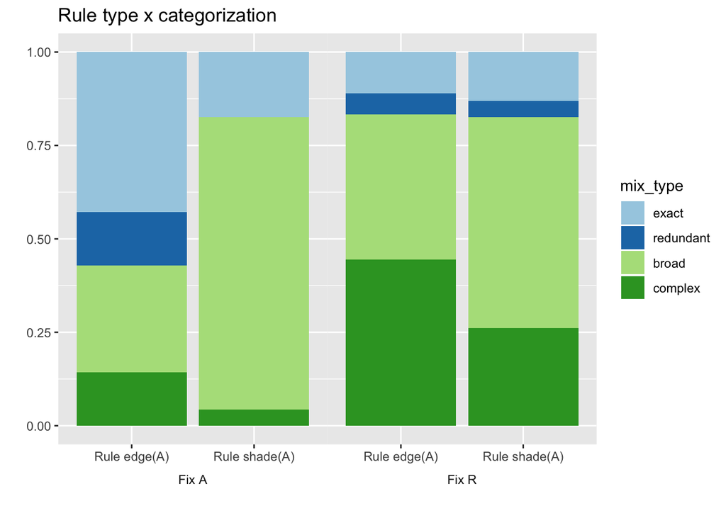

```r
glm(mix_type=='complex' ~ fix + rule_change,
    data=mix, family='binomial') %>% summary()
```

```
##
## Call:
## glm(formula = mix_type == "complex" ~ fix + rule_change, family = "binomial",
##     data = mix)
##
## Deviance Residuals:
##     Min       1Q   Median       3Q      Max
## -1.1091  -0.7571  -0.5279  -0.3369   2.4072
##
## Coefficients:
##                  Estimate Std. Error z value Pr(>|z|)
## (Intercept)       -1.9005     0.5633  -3.374 0.000742 ***
## fixR               1.7376     0.6338   2.741 0.006118 **
## rule_changeshade  -0.9402     0.5784  -1.626 0.104056
## ---
## Signif. codes:  0 '***' 0.001 '**' 0.01 '*' 0.05 '.' 0.1 ' ' 1
##
## (Dispersion parameter for binomial family taken to be 1)
##
##     Null deviance: 87.769  on 84  degrees of freedom
## Residual deviance: 76.712  on 82  degrees of freedom
## AIC: 82.712
##
## Number of Fisher Scoring iterations: 5
```

```r
glm(mix_type=='complex' ~ fix + rule_change + fix * rule_change,
    data=mix, family='binomial') %>% summary()
```

```
##
## Call:
## glm(formula = mix_type == "complex" ~ fix + rule_change + fix *
##     rule_change, family = "binomial", data = mix)
##
## Deviance Residuals:
##     Min       1Q   Median       3Q      Max
## -1.0842  -0.7775  -0.5553  -0.2982   2.5042
##
## Coefficients:
##                       Estimate Std. Error z value Pr(>|z|)
## (Intercept)            -1.7918     0.6236  -2.873  0.00406 **
## fixR                    1.5686     0.7835   2.002  0.04528 *
## rule_changeshade       -1.2993     1.1975  -1.085  0.27793
## fixR:rule_changeshade   0.4810     1.3728   0.350  0.72607
## ---
## Signif. codes:  0 '***' 0.001 '**' 0.01 '*' 0.05 '.' 0.1 ' ' 1
##
## (Dispersion parameter for binomial family taken to be 1)
##
##     Null deviance: 87.769  on 84  degrees of freedom
## Residual deviance: 76.585  on 81  degrees of freedom
## AIC: 84.585
##
## Number of Fisher Scoring iterations: 5
```

**No effects for other rule types.**

## Feature sources

For the result stone M, reference its feature change(s):

- **A**: with respect to the Active stone
- **R**: with respect to the Inactive stone
- **Constant**: a particular value in all cases
- **Multiple**: particular values case by case
- **General**: a broad description such as the feature simply “changes”
- **Unstated**: leave the feature unmentioned

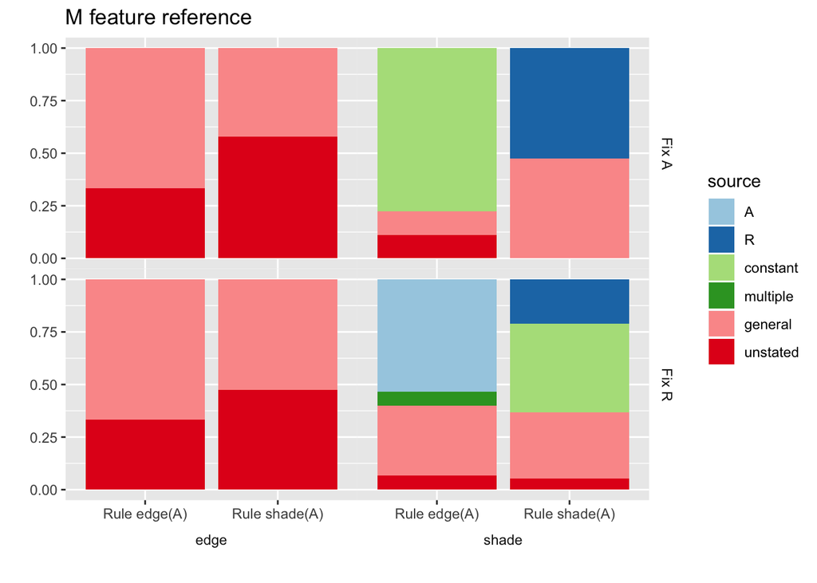

# Model fitting results

Models: DP(A), DP(R), DP(AR)

**Consider a mixture model DP(A|R) with respect to the condition?**

Fitted parameters:

- alpha = 1, 2, 3, 4, 5, 6, 7, 8, 9, 10, 16, 32, 64, 128, 256, 512, 1024
- beta = 0, 0.1, 0.2, 0.3, 0.4, 0.5, 0.6, 0.7, 0.8, 0.9, 1, 2, 4, 8, 16, 32, 64, 128, 256, 512, 1024
- inverse temperature `b`: higher => more confidence

## Model fits

### On all data points (N=102)

[output not shown]

### On people that pass both check trials (N=53)

| Model | Log likelihood | BIC | Parameters |
| --- | --- | --- | --- |
| Random baseline | -2540 | 5081 |  |
| Non-DP | -1547 | 3102 | b=3.9 |
| **DP(A)** | **-1365** | **2742** | alpha=5, beta=0.4, b=10.9 |
| DP(R) | -1403 | 2818 | alpha=10, beta=0.6, b=12.6 |
| DP(AR) | -1405 | 2822 | alpha=10, beta=512, b=12.5 |

## Sensitivity plots

Raw likelihood on 102 participants

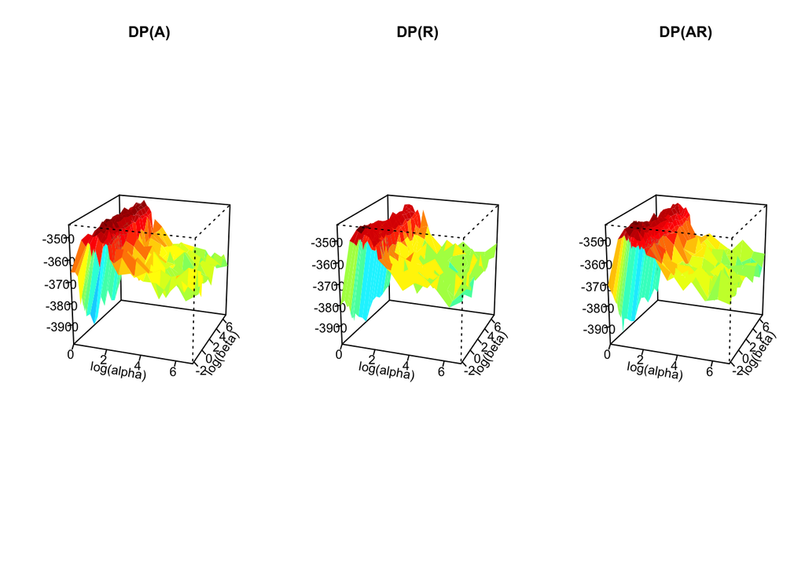

Fitted likelihood on 102 participants

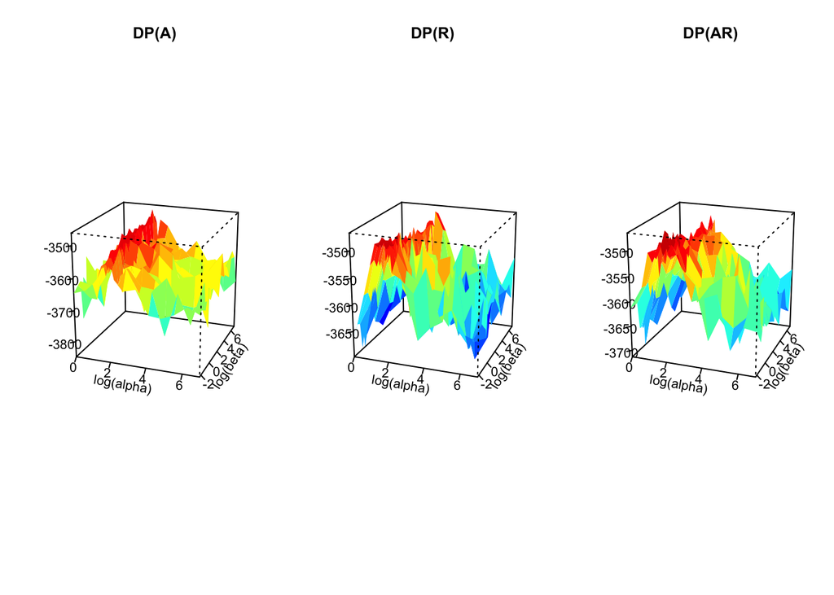

Raw likelihood on 53 pass-check-trials participants

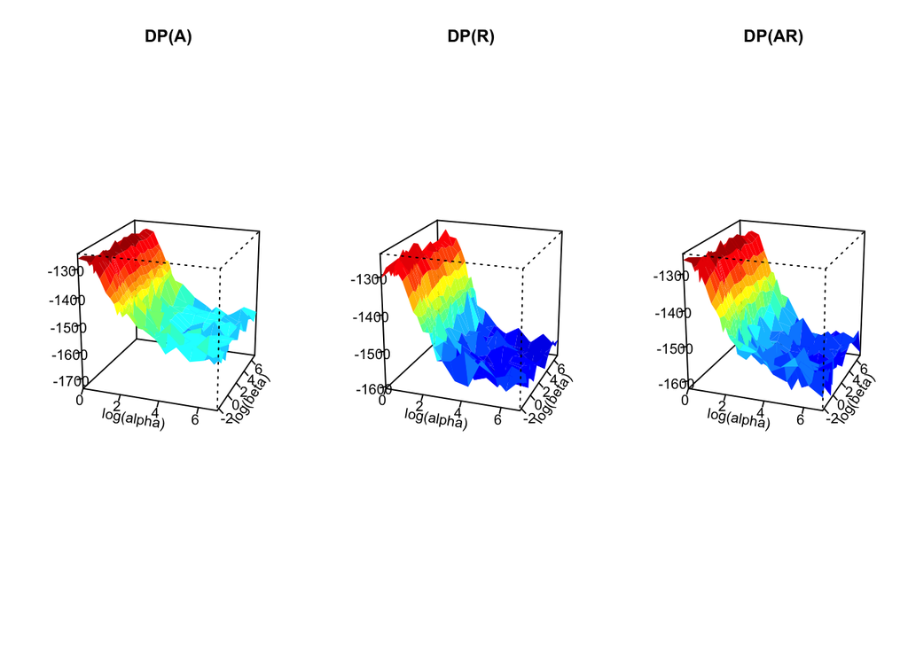

Fitted likelihood on 53 pass-check-trials participants

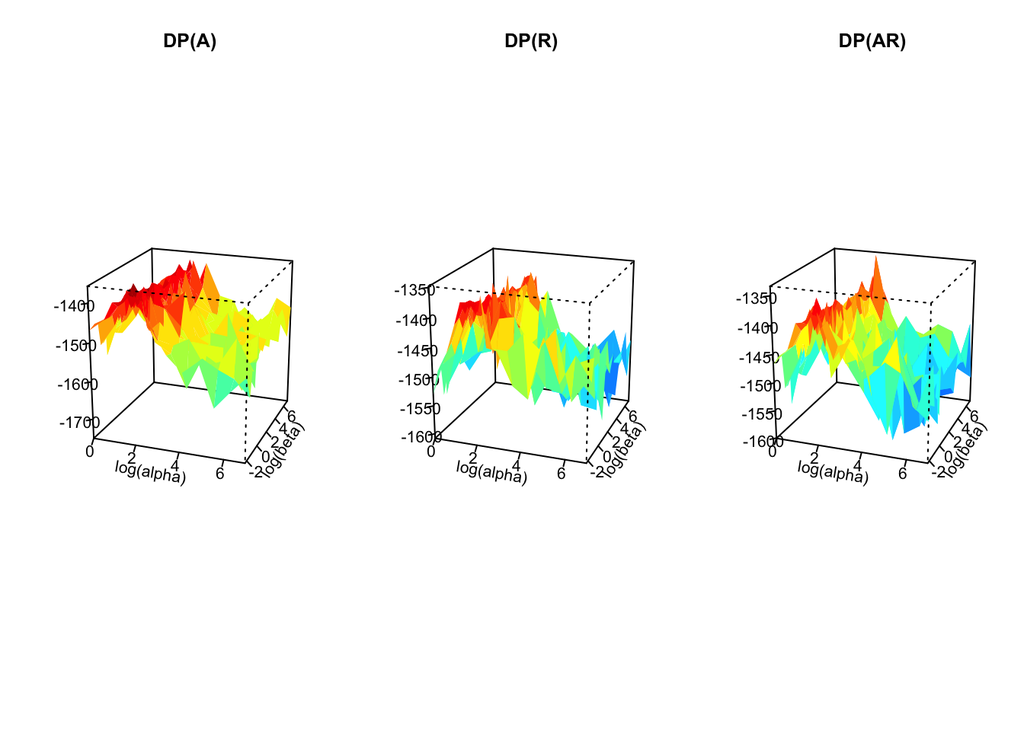

# Other ideas

- Classify participant *selections*, not free responses, of causal rules (equivalent classed)
- This 2 x 2 design leads to a different 2 x 2 interpretation: instead of evaluating the underlying causal rule as changes to A’s shade + 1 etc, it could also be interpreted as something like this

  |  | Fix A | Fix R |
  | --- | --- | --- |
  | M constant edge change | A1 | A3 |
  | M constant shade change | A4 | A2 |

  This seems to have a effect on the causal relations that people conclude: the causal relation is shaped by both the cause and the effect. Our DP model so far focus on deliberating over causes, but it seems people also take a lot of info from the Result itself to construct their causal understanding of what’s going on.